# Intro to Likelihood-free Inference using pytorch-lightning

### subMIT Workshop IAP 2024

#### Deep Chatterjee (deep1018@mit.edu), LIGO Lab & A3D3

- Brief background on likelihood-free inference
- Look at a simple problem - *Linear regression*
  - Infer slope and intercept of a line given noisy data
  - Work out the answer analytically
  - Do the same using stochastic sampling - MCMC/nested sampling
  - Do the same using posterior estimation via a normalizing flow using `pyro`
- Introduce `pytorch-lightning` and do the same problem using distributed training

# Background

# Inference

$$\text{We have a model}\;f(\mathbf{\Theta}) \rightarrow \text{Collect data}\;\mathbf{d} \rightarrow \text{infer signal parameters}\;\mathbf{\Theta}\;$$

- Terminology
  - **Signal**: True model i.e., data in absence of noise
  - **Data**: Signal + Noise
  - $\mathbf{d} = f(\mathbf{\Theta}) + n$
- *Noise* in experiments causes measurement *uncertainties*
- Noise $\rightarrow$ probability distribution of data, $\mathbf{d}$ for the same parameters, $\mathbf{\Theta}$.

$$ \text{Likelihood}\;L \equiv p(\mathbf{d}\vert\mathbf{\Theta}) $$

- As noise $\rightarrow 0$, $L \rightarrow \delta[\mathbf{d} - f(\mathbf{\Theta})]$.
- In bayesian inference, we want the posterior,

$$p(\mathbf{\Theta}\vert\mathbf{d}) = \frac{p(\mathbf{d}\vert\mathbf{\Theta})\;p(\mathbf{\Theta})}{p(\mathbf{d})}$$

- Generally done using stochastic sampling techniques (MCMC, nested sampling)
  - Propose $\mathbf{\Theta}_i \sim p(\mathbf{\Theta})$
  - Generate signal $f(\mathbf{\Theta}_i)$
  - Compute likelihood $L_i \rightarrow$ Accept/Reject proposed point.
  - Repeat...

# Linear model

\begin{align} y_i = \underbrace{mx_i + c}_{\text{true model }f(x_i)} + \epsilon_i. \end{align}

[figure not shown]

- We want to estimate slope and intercept, $\{m, c\}$
- Data is noisy. Assume $\epsilon \sim \mathcal{N}(0, \sigma^2)$.

# Likelihood

- The noise term, $\epsilon\sim \mathcal{N}(0, \sigma^2)$ \begin{align} L(\{y_i\} \vert m, c, \sigma) &\propto \exp\left[-\frac{1}{2\sigma^2}\sum_i\left(y_i - mx_i - c\right)^2\right] \end{align}
- Maximize the likelihood

\begin{align} \frac{\partial L}{\partial m} = \frac{\partial L}{\partial c} = 0 \end{align}

- Least square answer

\begin{align} \hat{m} = \frac{\sum x_iy_i}{\sum x_i^2}\;\;\;;\;\; \hat{c} = \frac{\sum y_i}{n}. \end{align}

- Re-express likelihood around maximum $\{\hat{m}, \hat{c}\}$

\begin{align} L(\{y_i\} \vert m, c, \sigma) &\propto \exp{\left[-\frac{\sum x_i^2}{2\sigma^2}\left(m - \hat{m}\right)^2\right]} \times \exp{\left[-\frac{n}{2\sigma^2}\left(c - \hat{c}\right)^2\right]}. \end{align}

- The likelihood is a gaussian around the least square values.
- Corresponding widths are $\Delta m \sim \left(\sigma/\sqrt{\sum x_i^2}\right)$ and $\Delta c \sim \left(\sigma/\sqrt{n}\right)$.

# Posterior

\begin{align} p(m, c, \sigma \vert \{y_i\}) \propto L(\{y_i\} \vert m, c, \sigma)\;p(m)\;p(c)\;p(\sigma) \end{align}

- Assume uninformative priors on parameters, $p(m)\;,\; p(c) \sim 1$.
- Assume $\sigma$ is known i.e. $p(\sigma') = \delta(\sigma - \sigma')$.
- The posterior is also a gaussian (same as the likelihood in this example).

## Marginals

\begin{align} p(m\vert \{y_i\}) &\propto \int L(\{y_i\}\vert m, c, \sigma')\;\underbrace{p(m)\;p(c)}_{\sim 1}\;\overbrace{p(\sigma)}^{\sim \delta(\sigma - \sigma')} dc\;d\sigma' \\ &\propto \exp{\left[-\frac{\sum x_i^2}{2\sigma^2}\left(m - \hat{m}\right)^2\right]}. \end{align}

\begin{align} p(c\vert \{y_i\}) &\propto \int L(\{y_i\}\vert m, c, \sigma')\;{p(m)\;p(c)}\;{p(\sigma)}\;dm\;d\sigma' \\ &\propto \exp{\left[-\frac{n}{2\sigma^2}\left(c - \hat{c}\right)^2\right]}. \end{align}

### Putting some numbers

```python
injection_parameters = dict(m=0.8, c=2)
```

```python
num_points = 50
x = np.linspace(-4, 4, num_points)
```

```python
sigma = 0.6
```

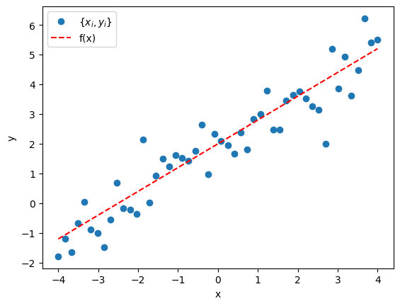

```python
fig, ax = plt.subplots()
ax.plot(x, data, 'o', label='$\\{x_i, y_i\\}$')
ax.plot(x, linear_model(x, **injection_parameters), '--r', label='f(x)')
ax.legend()
ax.set_xlabel('x')
ax.set_ylabel('y')
```

```python
m_hat = (x * data).sum() / (x * x).sum()
c_hat = data.sum() / num_points

delta_m = sigma/np.sqrt(np.sum((x)**2))
delta_c = sigma * np.sqrt(1/num_points)

print("Expected m = {:.3f} +/- {:.3f}".format(m_hat, delta_m))
```

```
Expected m = 0.801 +/- 0.036
```

```python
print("Expected c = {:.3f} +/- {:.3f}".format(c_hat, delta_c))
```

```
Expected c = 1.909 +/- 0.085
```

## Result from nested sampling

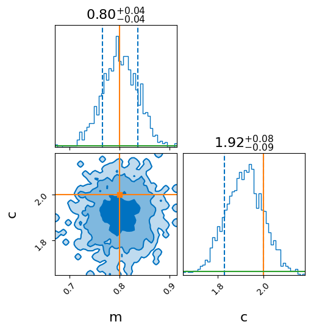

```python
result.plot_corner(priors=True, quantiles=(0.16, 0.84))
```

# Same problem using likelihood-free inference

By posterior estimation using a normalizing flow

- We can simulate signals
  - Given $\mathbf{\Theta}_i \sim p(\mathbf{\Theta}) \rightarrow$ generate signal $f(\mathbf{\Theta}_i)$
  - Add instrument noise $f(\mathbf{\Theta}_i) + n \rightarrow \mathbf{d}_i$
- We can "easily" get pairs $\{\mathbf{\Theta}_i, \mathbf{d}_i\}$
- From $\{\mathbf{\Theta}_i, \mathbf{d}_i\} \rightarrow p(\mathbf{\Theta}, \mathbf{d}), p(\mathbf{\Theta}\vert \mathbf{d}), p(\mathbf{d}\vert\mathbf{\Theta})$
- Here, we are interested in the posterior estimation
- The distributions are complex
- A solution is to use a Normalizing flow
  - Contains a **learnable transform** (a trainable neural network)
  - A **base distribution** (often taken to be normal)
- Here we use a affine-autogressive transform from `pyro`
- A standard normal base distribution

## Result from normalizing flow

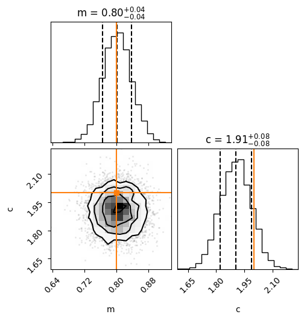

```python
live_plot_samples(flow_samples, truth)
```